# Troubleshooting REDCap API Calls

There are many links in the pipeline between your institution's [REDCap](http://www.project-redcap.org/) server and the API user. When the end result is unsuccesful, this document should help narrow the location of the possible problem. The first two sections will be relevant to almost any language interacting with the API. The remaining sections are possibly relevant only to your language (eg, Python, R, SAS, bash), or your software library (redcapAPI and REDCapR in R and [PyCap](http://pycap.readthedocs.org/en/latest/) in Python).

## Server Configuration and Authorization

This first group of checks primarily focuses on the server and the logins accounts. Unlike later sections, REDCap administrator privileges are necessary for most of these checks.

1. **Does the user have an account for the *server*?** This can be verified in the `Browse Users` section of the server's `Control Center`.
2. **Does the user have permissions for the specific *project*?** This can be verified in the `User Rights` section within the project. Notice that it's possible (but ultimately not useful) to have an account here, but not with the server, so don't skip the previous step.
3. **Can the user login in normally through the interface?** However if the username and password aren't working, the API theoretically might still work because it uses their token instead of their password.
4. **Has the user verified their account by responding to the automated email sent to them?** This can be verified in the `Browse Users` section of your server's `Control Center`. For each email address they've entered, there should be a green 'Verified' label and icon.
5. **Has the user been granted the desired import and/or export permissions?** This can be verified in the `User Rights` section or in the `API` section (and it's `Manage All Project Tokens` tab) within the project. Alternatively, it can be verified in the `API Tokens` section of the server's `Control Center`.

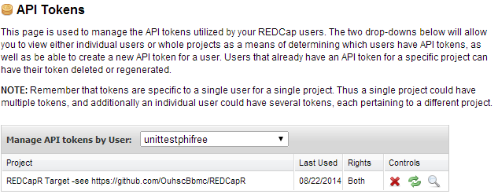

6. **Are they using the correct token?** This can be verified in the `API` section (and it's `Manage All Project Tokens` tab) within the project. Click the magnifying glass icon in the user's row. Alternatively, it can be verified in the `API Tokens` section of the server's `Control Center`.

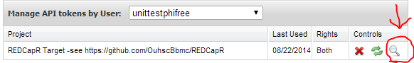

## Language Agnostic API

This section group examines potential problems that occur after it leaves a working server, but before it is handled by their programming language (eg, Python and R). [Postman](http://www.getpostman.com/) is a Chrome plugin recommended by [several](https://groups.google.com/forum/#!searchin/project-redcap/postman/project-redcap/eYK_SLzW2k4/0hmf8vWLpdAJ) [people](https://groups.google.com/forum/#!searchin/project-redcap/postman/project-redcap/RdLeRFGqzbg/WgdjTBLph1kJ) that makes troubleshooting much more efficient.

[figure not shown]

1. **Is Postman installed and operating correctly?**  
   If it helps to start with a different REDCap server, you can use this dummy project containing fake data hosted by the [OUHSC BBMC](http://ouhsc.edu/bbmc/). The url is `https://bbmc.ouhsc.edu/redcap/api/`. There are three key-value pairs: (1) the 'token' is `9A81268476645C4E5F03428B8AC3AA7B`, (2) the 'content' is `record`, and (3) the 'format' should be `CSV`. When checking your own server, the token value should change, but the content and format should not. It should return five records in a CSV format. The 'status' should be `200 OK`. The result should look roughly like this. Notice the line breaks were included in the text values themselves.

   ```
   record_id,name_first,name_last,address,telephone,email,dob,age,ethnicity,race,sex,height,weight,bmi,comments,demographics_complete
   "1","Nutmeg","Nutmouse","14 Rose Cottage St.
   Kenning UK, 323232","(432) 456-4848","nutty@mouse.com","2003-08-30",10,1,2,0,5,1,400,"Character in a book, with some guessing",2
   "2","Tumtum","Nutmouse","14 Rose Cottage Blvd.
   Kenning UK 34243","(234) 234-2343","tummy@mouse.comm","2003-03-10",10,1,6,1,6,1,277.8,"A mouse character from a good book",2
   "3","Marcus","Wood","243 Hill St.
   Guthrie OK 73402","(433) 435-9865","mw@mwood.net","1934-04-09",79,0,4,1,180,80,24.7,"completely made up",2
   "4","Trudy","DAG","342 Elm
   Duncanville TX, 75116","(987) 654-3210","peroxide@blonde.com","1952-11-02",61,1,4,0,165,54,19.8,"This record doesn't have a DAG assigned

   So call up Trudy on the telephone
   Send her a letter in the mail",2
   "5","John Lee","Walker","Hotel Suite
   New Orleans LA, 70115","(333) 333-4444","left@hippocket.com","1955-04-15",58,1,4,1,193.04,104,27.9,"Had a hand for trouble and a eye for cash

   He had a gold watch chain and a black mustache",2
   ```

2. **Can an administrator query the API successfully with Postman with the admin token?** As an administrator, create an account for yourself, and verify that your token works on your server and project.
3. **Can an administrator query the API successfully with Postman with the user's token?** Use [Postman](http://www.getpostman.com/) as before, but replace your token with the user's token. Once the whole problem is solved, reissue new API tokens to both you and the user.
4. **Can an user query the API successfully with Postman with the their own token?** The values they enter should be exactly the same as those entered in the previous step. A failure here (assuming the previous step was successful) suggests a network or firewall issue. If the server is behind your institution's firewall, verify the user is connecting successfully through the VPN.

## Exporting from REDCap to R

There are several ways to call REDCap's API from [R](http://cran.r-project.org/). The packages redcapAPI and REDCapR both rely on the [httr](http://cran.r-project.org/web/packages/httr/index.html) package, which calls the RCurl package.

1. **Is RCurl installed on the user's local machine?** If so, running `library(RCurl)` should produce the following output if you're starting with a fresh session of R:

   ```r
   > library(RCurl)
   ## Loading required package: RCurl
   ## Loading required package: bitops
   ```

2. **Does the user have the most recent version of RCurl?**  
   There are several ways to do this, but the easiest is probably to run `update.packages(ask=FALSE, repos="http://cran.rstudio.com")`. The optional argument `ask` prevents the user from needing to respond 'Y' to each outdated package.
3. **Can the user query a *test* project using RCurl?** Both the redcapAPI and REDCapR packages employ something similar to the following function in RCurl. If you're curious, here is the relevant source code for [redcapAPI](https://github.com/nutterb/redcapAPI/blob/master/R/exportRecords.R) and [REDCapR](https://github.com/OuhscBbmc/REDCapR/blob/master/R/redcap_read_oneshot.R).

   If this check fails, consider attempting again with the uri and token used above in the Postman example.

   This check avoids SSL in order to simplify the troubleshooting. SSL is supported by default in the [PyCap](http://pycap.readthedocs.org/en/latest/) and REDCapR packages.

   ```r
   redcap_uri <- "https://bbmc.ouhsc.edu/redcap/api/"
   token <- "9A81268476645C4E5F03428B8AC3AA7B"

   raw_text <- RCurl::postForm(
     uri = redcap_uri
     , token = token
     , content = 'record'
     , format = 'csv'
     , type = 'flat'
     , rawOrLabel = 'raw'
     , exportDataAccessGroups = 'true'
     , .opts = RCurl::curlOptions(ssl.verifypeer=FALSE)
   )
   ```

   Alternatively, you can try using the [`httr`](http://cran.r-project.org/web/packages/httr/) package, which uses `RCurl` underneath. [`REDCapR`](https://github.com/OuhscBbmc/REDCapR) and a recent fork of [`redcap`](https://github.com/nutterb/redcap) actually uses `httr` directly, instead of `RCurl`. As of 2014-07-06, this works with the Windows 8 version for [libcurl](http://curl.haxx.se/libcurl/) (which is underneath RCurl), but not with some Linux versions; in this case pass the location of the SSL cert file.

   ```r
   post_body <- list(
     token = token,
     content = 'record',
     format = 'csv',
     type = 'flat',
     rawOrLabel = 'raw',
     exportDataAccessGroups = 'true'
   )

   raw_text <- httr::POST(
     url = redcap_uri,
     body = post_body,
     config = httr::config(ssl.verifypeer=FALSE),
     httr::verbose() #Remove this line to suppress the frequent console updates.
   )
   ```

4. **Can the user query a *subset* of *their* project using RCurl?**  
   This step is like the previous one, but with two differences. First, it's using their REDCap project (instead of the test project). Second, it pulls fewer records, and a smaller collection of fields. Subsetting can help troubleshoot by avoiding (and thus identifying) cells with problematic values.

   Notice this call to `RCurl::postForm()` now passes values to the `records` and `fields` parameters. Also notice the value is a *single* long string, rather a *vector* of shorter strings (which is more natural to most R users).

   ```r
   redcap_uri <- "https://the.urlofyourinsitution.edu/api/" #Adapt this to your server.
   token <- "your-secret-token" #Adapt this to your user's token.
   records_collapsed <- "1,2,3" #This assumes that their dataset contains ID values of 1, 2, and 3.  Adapt this to their dataset.
   fields_collapsed <- "record_id,name_first,name_last" #This assumes that their dataset contains variables called 'record_id', 'name_first', and 'name_last'.  Adapt this to their dataset.

   raw_text <- RCurl::postForm(
     uri = redcap_uri
     , token = token
     , content = 'record'
     , format = 'csv'
     , type = 'flat'
     , rawOrLabel = 'raw'
     , exportDataAccessGroups = 'true'
     , records = records_collapsed
     , fields = fields_collapsed
     , .opts = RCurl::curlOptions(ssl.verifypeer=FALSE)
   )
   ```

5. **Can the user query an *entire* project using RCurl?** There are two advantages of trying a subset of the data. First, small datasets avoid the time-out errors that plague large datasets. Second, it may avoid problematic values being passed through the pipeline. If the current check fails but the previous check succeedes, then experiment with different expanses of records and fields. This should help determine which values are causing the problems, or if there's simply too much data being pulled in one pass.

   If the desired dataset is too large, consider if you can prune unnecessary records or fields. If not, one solution is to pull smaller, multiple batches using the API, then reassemble them. The `redcap_read()` function in [REDCapR](https://github.com/OuhscBbmc/REDCapR/blob/master/DocumentationPeek.pdf) does this automatically, and allows the user to specify a `batch_size`.

   ```r
   redcap_uri <- "https://the.urlofyourinsitution.edu/api/" #Adapt this to your server.
   token <- "your-secret-token" #Adapt this to your user's token.
   records_collapsed <- NULL
   fields_collapsed <- NULL

   raw_text <- RCurl::postForm(
     uri = redcap_uri
     , token = token
     , content = 'record'
     , format = 'csv'
     , type = 'flat'
     , rawOrLabel = 'raw'
     , exportDataAccessGroups = 'true'
     , records = records_collapsed
     , fields = fields_collapsed
     , .opts = RCurl::curlOptions(ssl.verifypeer=FALSE)
   )
   ```

## Exporting from REDCap to R, using REDCapR

REDCapR is a package that uses RCurl (via httr) to communicate with REDCap, and wraps convience functions around it to reduce the size and complexity of the user's code. The package's basic functions are demonstrated in [this vignette](http://htmlpreview.github.io/?https://github.com/OuhscBbmc/REDCapR/blob/master/inst/doc/BasicREDCapROperations.html) and are documented in its [reference manual](https://github.com/OuhscBbmc/REDCapR/blob/master/DocumentationPeek.pdf) (click the 'View Raw' link).

If you're not using REDCapR, you can skip this section and proceed to 'Importing into REDCap from R' below.

1. **Is REDCapR installed on the user's machine?**  
   Currently the easiest way to install REDCapR is with the devtools. The follow code installs devtools, then installs REDCapR.

   ```r
   install.packages("devtools", repos="http://cran.rstudio.com")
   devtools::install_github(repo="OuhscBbmc/REDCapR")
   ```

2. **Does REDCapR load successfully on the user's machine?**  
   If so, running `library(REDCapR)` should produce the following output if you're starting with a fresh session of R:

   ```r
   library(REDCapR)
   ## Loading required package: REDCapR
   ```

3. **Can the user export from an example project?**  
   This is the same fake data hosted by the [OUHSC BBMC](http://ouhsc.edu/bbmc/) as in the previous section.

   ```r
   library(REDCapR) #Load the package into the current R session.
   uri <- "https://bbmc.ouhsc.edu/redcap/api/"
   token <- "9A81268476645C4E5F03428B8AC3AA7B"
   redcap_read(redcap_uri=uri, token=token)$data
   ```

   The previous code should produce similar output. Notice there are five rows and the columns will wrap around if your console window is too narrow.

   ```
   5 records and 1 columns were read from REDCap in 0.41 seconds.
   Starting to read 5 records  at 2014-06-27 17:19:49
   Reading batch 1 of 1, with ids 1 through 5.
   5 records and 16 columns were read from REDCap in 0.42 seconds.

   record_id name_first name_last                                 address      telephone               email
   1         1     Nutmeg  Nutmouse 14 Rose Cottage St.\nKenning UK, 323232 (432) 456-4848     nutty@mouse.com
   2         2     Tumtum  Nutmouse 14 Rose Cottage Blvd.\nKenning UK 34243 (234) 234-2343    tummy@mouse.comm
   3         3     Marcus      Wood          243 Hill St.\nGuthrie OK 73402 (433) 435-9865        mw@mwood.net
   4         4      Trudy       DAG          342 Elm\nDuncanville TX, 75116 (987) 654-3210 peroxide@blonde.com
   5         5   John Lee    Walker      Hotel Suite\nNew Orleans LA, 70115 (333) 333-4444  left@hippocket.com

        dob age ethnicity race sex height weight   bmi
   1 2003-08-30  10         1    2   0   5.00      1 400.0
   2 2003-03-10  10         1    6   1   6.00      1 277.8
   3 1934-04-09  79         0    4   1 180.00     80  24.7
   4 1952-11-02  61         1    4   0 165.00     54  19.8
   5 1955-04-15  58         1    4   1 193.04    104  27.9

                                                                                                    comments
   1                                                                     Character in a book, with some guessing
   2                                                                          A mouse character from a good book
   3                                                                                          completely made up
   4 This record doesn't have a DAG assigned\n\nSo call up Trudy on the telephone\nSend her a letter in the mail
   5                 Had a hand for trouble and a eye for cash\n\nHe had a gold watch chain and a black mustache

   demographics_complete
   1                     2
   2                     2
   3                     2
   4                     2
   5                     2
   ```

4. **Can the user export from their own project?** The code is similar to the previous check, but the `uri` and `token` values will need to be modified.

   ```r
   library(REDCapR) #Load the package into the current R session, if you haven't already.
   redcap_uri <- "https://the.urlofyourinsitution.edu/api/" #Adapt this to your server.
   token <- "your-secret-token" #Adapt this to your user's token.
   redcap_read(redcap_uri=uri, token=token)$data
   ```

   Alternatively, a `redcap_project` object can be declared initially, which makes subsequent calls cleaner when the token and url are required only the when the object is declared.

   ```r
   library(REDCapR) #Load the package into the current R session, if you haven't already.
   uri <- "https://bbmc.ouhsc.edu/redcap/api/"
   token <- "9A81268476645C4E5F03428B8AC3AA7B"
   project <- redcap_project$new(redcap_uri=uri, token=token)

   dsThreeColumns <- project$read(fields=c("record_id", "sex", "age"))$data

   idsOfMales <- dsThreeColumns[dsThreeColumns$sex==1, "record_id"]
   idsOfMinors <- dsThreeColumns[dsThreeColumns$age < 18, "record_id"]

   dsMales <- project$read(records=idsOfMales, batch_size=2)$data
   dsMinors <- project$read(records=idsOfMinors)$data
   ```

5. **Is the export operation still unsuccessful using REDCapR?** If so the “Can the user query a *entire* REDCap project using RCurl?” check succeeded, but the REDCapR checks did not, consider posting a new [GitHub issue](https://github.com/OuhscBbmc/REDCapR/issues) to the package developers.

## Exporting from REDCap to R, using redcapAPI

If you're not using redcapAPI, you can skip this section and proceed to 'Importing into REDCap from R' below. More specific discussion about `redcapAPI` can be found at the [package's wiki](https://github.com/nutterb/redcapAPI/wiki).

1. **Is redcapAPI installed on the user's machine?**  
   Currently, the easiest way to install `redcapAPI` is from CRAN.

   ```r
   install.packages("redcapAPI")
   ```

   Developmental versions may be available on GitHub.

   ```r
   install.packages("devtools", repos="http://cran.rstudio.com")
   devtools::install_github(repo="nutterb/redcapAPI")
   ```

2. **Does redcapAPI load successfully on the user's machine?**  
   If so, running `library(redcapAPI)` should produce the following output if you're starting with a fresh session of R:

   ```r
   library(redcapAPI)
   ## Loading required package: redcapAPI
   ```

3. **Can the user export from an example project?**  
   This is the same fake data hosted by the [OUHSC BBMC](http://ouhsc.edu/bbmc/) as in the previous section.

   ```r
   library(redcapAPI) #Load the package into the current R session.
   rcon <- redcapConnection(url = "https://bbmc.ouhsc.edu/redcap/api/",
                            token = "9A81268476645C4E5F03428B8AC3AA7B")
   exportRecords(rcon)
   ```

   The previous code should produce similar output. Notice there are five rows and the columns will wrap around if your console window is too narrow.

   ```
   record_id name_first name_last                                 address      telephone               email
   1         1     Nutmeg  Nutmouse 14 Rose Cottage St.\nKenning UK, 323232 (432) 456-4848     nutty@mouse.com
   2         2     Tumtum  Nutmouse 14 Rose Cottage Blvd.\nKenning UK 34243 (234) 234-2343    tummy@mouse.comm
   3         3     Marcus      Wood          243 Hill St.\nGuthrie OK 73402 (433) 435-9865        mw@mwood.net
   4         4      Trudy       DAG          342 Elm\nDuncanville TX, 75116 (987) 654-3210 peroxide@blonde.com
   5         5   John Lee    Walker      Hotel Suite\nNew Orleans LA, 70115 (333) 333-4444  left@hippocket.com

        dob age ethnicity race sex height weight   bmi
   1 2003-08-30  10         1    2   0   5.00      1 400.0
   2 2003-03-10  10         1    6   1   6.00      1 277.8
   3 1934-04-09  79         0    4   1 180.00     80  24.7
   4 1952-11-02  61         1    4   0 165.00     54  19.8
   5 1955-04-15  58         1    4   1 193.04    104  27.9

                                                                                                    comments
   1                                                                     Character in a book, with some guessing
   2                                                                          A mouse character from a good book
   3                                                                                          completely made up
   4 This record doesn't have a DAG assigned\n\nSo call up Trudy on the telephone\nSend her a letter in the mail
   5                 Had a hand for trouble and a eye for cash\n\nHe had a gold watch chain and a black mustache

   demographics_complete
   1                     2
   2                     2
   3                     2
   4                     2
   5                     2
   ```

4. **Can the user export from their own project?** The code is similar to the previous check, but the `uri` and `token` values will need to be modified.

   ```r
   library(redcapAPI) #Load the package into the current R session, if you haven't already.
   rcon <- redcapConnection(url = "https://the.urlofyourinsitution.edu/api/", #Adapt this to your server.
                          token = "your-secret-token") #Adapt this to your user's token.
   exportRecords(rcon)
   ```

5. **Is the export operation still unsuccessful using redcapAPI?** If so the “Can the user query a *entire* REDCap project using RCurl?” check succeeded, but the redcapAPI checks did not, consider posting a new [GitHub issue](https://github.com/nutterb/redcapAPI/issues) to the package developers.

## Importing into REDCap from R

Troubleshooting import operations is trickier than export operations for two major reasons. First, the database potentially persists your *import* mistakes. In contrast, repeatedly *exporting* data won't affect subsequent reads. Considering cloning the REDCap project for testing until the problem is resolved. Remember to create a new token (because they're not automatically created when projects are cloned, even when users are copied), and to modify your code's token to point to the new testing clone.

The second reason why importing can be trickier is because the schema (eg, the names and data types) of your local dataset must match the project's schema. This section will be expanded in the future. Current recommendations include checking if you can write to simpler projects (perhaps with 1 ID field and 1 string field), and progressively moving to mimic the problematic project's schema and dataset. Also, consider exporting the dataset to your machine, and look for differences. Note that you cannot import calculated fields into REDCap.

1. **Can the user import the *entire* project?**
2. **Can the user import a *subset* of the project?**

## Other software for communication and automation with REDCap

REDCap is used in many enviroments, andit's not surprising that a lot of libraries have been developed that cater to different scenarios and languages. Here's a partial list, and please email me if there are more that should be included. **Actively developed in the past two years**

1. [`PyCap`](http://sburns.org/PyCap/): “PyCap is an interface to the REDCap Application Programming Interface (API). PyCap is designed to be a minimal interface exposing all required and optional API parameters.” (Written in Python primarily by Scott Burns, formerly with Vanderbilt, now at [Stratasan](http://www.stratasan.com/).)
2. [`redcap`](https://github.com/jeffreyhorner/redcap): “R interface to REDCap.” (Written in R primarily by Jeffrey Horner. The last commit was Feb 2013)
3. [`redcapAPI`](https://github.com/nutterb/redcapAPI): This is the most actively-developed fork of the library above. (Written in R primarily by Benjamin Nutter at the Cleveland Clinic Foundation.)
4. [`REDCapR`](https://github.com/OuhscBbmc/REDCapR): “R Utilities for interacting with a REDCap data system.” (Written in R primarily by Will Beasley, and the [OUHSC BBMC](http://ouhsc.edu/bbmc/).
5. [`redcap-repeat`](https://github.com/cbmi/redcap-repeat): “Script for REDCap data dictionaries to support repeating fields and groups of fields.” (Written in Python primarily by Jeff Max at CHOP's [CBMI](https://github.com/cbmi)).
6. [`django-redcap`](https://github.com/cbmi/django-redcap): “Utilities for porting REDCap projects to and from Django models.” (Written in Python primarily by 'dmegahan at CHOP's [CBMI](https://github.com/cbmi)).

## Other good resources

- The basic API documentation is available on your REDCap server, typically at http://<*your server name*>/redcap/api/help.
- If you have access to the REDCap wiki, some newer examples might exist at https://iwg.devguard.com/trac/redcap/wiki/ApiExamples.
- Scott Burns, the developer of [PyCap](http://sburns.org/PyCap/) has a good intro at http://sburns.org/2013/07/22/intro-to-redcap-api.html
- Bejamin Nutter, the developer of [redcapAPI](https://github.com/nutterb/redcapAPI/wiki) has a good wiki at https://github.com/nutterb/redcapAPI/wiki
- In addition to this troubleshooting document, REDCapR has a [vignette](http://htmlpreview.github.io/?https://github.com/OuhscBbmc/REDCapR/blob/master/inst/doc/BasicREDCapROperations.html) that covers its basic operations.

## Document Info

This document is primarily based on REDCap version 5.11.3, and was last updated 2014-08-30. A development version of the document is available on GitHub: http://htmlpreview.github.io/?https://github.com/OuhscBbmc/REDCapR/blob/dev/inst/doc/TroubleshootingApiCalls.html.